# p8105_hw3_yl6377

2026-10-14

```r
library(tidyverse)
library(p8105.datasets)
library(patchwork)
library(lubridate)
library(janitor)
library(knitr)
```

#Problem 1

Data Import

```r
data("ny_noaa")

dim(ny_noaa)
```

```
## [1] 2595176       7
```

```r
names(ny_noaa)
```

```
## [1] "id"   "date" "prcp" "snow" "snwd" "tmax" "tmin"
```

```r
glimpse(ny_noaa)
```

```
## Rows: 2,595,176
## Columns: 7
## $ id   <chr> "US1NYAB0001", "US1NYAB0001", "US1NYAB0001", "US1NYAB0001", "US1N…
## $ date <date> 2007-11-01, 2007-11-02, 2007-11-03, 2007-11-04, 2007-11-05, 2007…
## $ prcp <int> NA, NA, NA, NA, NA, NA, NA, NA, NA, NA, NA, NA, NA, NA, NA, NA, 3…
## $ snow <int> NA, NA, NA, NA, NA, NA, NA, NA, NA, NA, NA, NA, NA, NA, NA, NA, 3…
## $ snwd <int> NA, NA, NA, NA, NA, NA, NA, NA, NA, NA, NA, NA, NA, NA, NA, NA, 0…
## $ tmax <chr> NA, NA, NA, NA, NA, NA, NA, NA, NA, NA, NA, NA, NA, NA, NA, NA, N…
## $ tmin <chr> NA, NA, NA, NA, NA, NA, NA, NA, NA, NA, NA, NA, NA, NA, NA, NA, N…
```

```r
head(ny_noaa)
```

```
## # A tibble: 6 × 7
##   id          date        prcp  snow  snwd tmax  tmin
##   <chr>       <date>     <int> <int> <int> <chr> <chr>
## 1 US1NYAB0001 2007-11-01    NA    NA    NA <NA>  <NA>
## 2 US1NYAB0001 2007-11-02    NA    NA    NA <NA>  <NA>
## 3 US1NYAB0001 2007-11-03    NA    NA    NA <NA>  <NA>
## 4 US1NYAB0001 2007-11-04    NA    NA    NA <NA>  <NA>
## 5 US1NYAB0001 2007-11-05    NA    NA    NA <NA>  <NA>
## 6 US1NYAB0001 2007-11-06    NA    NA    NA <NA>  <NA>
```

```r
colSums(is.na(ny_noaa))
```

```
##      id    date    prcp    snow    snwd    tmax    tmin
##       0       0  145838  381221  591786 1134358 1134420
```

```r
colMeans(is.na(ny_noaa))
```

```
##        id      date      prcp      snow      snwd      tmax      tmin
## 0.0000000 0.0000000 0.0561958 0.1468960 0.2280331 0.4371025 0.4371264
```

```r
missing_summary =
  tibble(
    variable = names(ny_noaa),
    n_missing = colSums(is.na(ny_noaa)),
    prop_missing = colMeans(is.na(ny_noaa))
  )

missing_summary
```

```
## # A tibble: 7 × 3
##   variable n_missing prop_missing
##   <chr>        <dbl>        <dbl>
## 1 id               0       0
## 2 date             0       0
## 3 prcp        145838       0.0562
## 4 snow        381221       0.147
## 5 snwd        591786       0.228
## 6 tmax       1134358       0.437
## 7 tmin       1134420       0.437
```

Clean data

```r
ny_noaa_clean =
  ny_noaa |>
  separate(
    date,
    into = c("year", "month", "day"),
    sep = "-"
  ) |>
  mutate(
    year = as.integer(year),
    month = as.integer(month),
    day = as.integer(day),
    tmax = as.numeric(tmax) / 10,
    tmin = as.numeric(tmin) / 10,
    prcp = as.numeric(prcp) / 10,
    snow = as.numeric(snow),
    snwd = as.numeric(snwd)
  )
```

The `ny_noaa` dataset contains 2595176 observations and 7 variables. Each row represents a weather observation at a particular weather station on a particular date. The key variables are id, date, prcp, snow, snwd, tmax, tmin. The dataset contains missing values in several weather variables, including 145838 missing precipitation values, 381221 missing snowfall values, 1134358 missing maximum temperature values, and 1134420 missing minimum temperature values.

For snowfall, what are the most commonly observed values? Why?

```r
ny_noaa_clean |>
  count(snow, sort = TRUE) |>
  slice_head(n = 10)
```

```
## # A tibble: 10 × 2
##     snow       n
##    <dbl>   <int>
##  1     0 2008508
##  2    NA  381221
##  3    25   31022
##  4    13   23095
##  5    51   18274
##  6    76   10173
##  7     8    9962
##  8     5    9748
##  9    38    9197
## 10     3    8790
```

The most common snowfall value is 0 because snowfall is a weather event that does not occur every day. Many observations are recorded on days when no snow falls, so zero appears more frequently than any positive snowfall value. In addition, the dataset includes observations from multiple weather stations and across many years, increasing the number of days with no snowfall.

A two panel plot

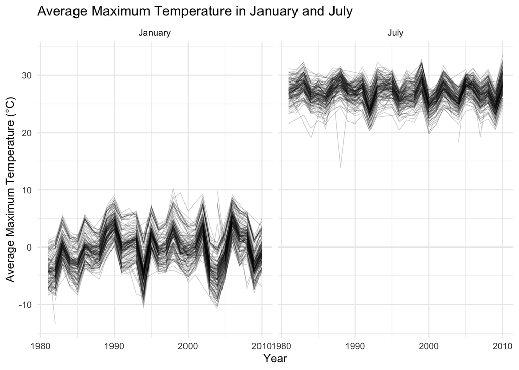

```r
monthly_tmax =
  ny_noaa_clean |>
  filter(month == 1 | month == 7) |>
  group_by(id, year, month) |>
  summarize(
    avg_tmax = mean(tmax, na.rm = TRUE),
    .groups = "drop"
  )

temperature_plot =
  ggplot(
    monthly_tmax,
    aes(x = year, y = avg_tmax, group = id)
  ) +
  geom_line(alpha = 0.2, linewidth = 0.3) +
  facet_wrap(
    ~ month,
    labeller = as_labeller(
      c("1" = "January", "7" = "July")
    )
  ) +
  labs(
    title = "Average Maximum Temperature in January and July",
    x = "Year",
    y = "Average Maximum Temperature (°C)"
  ) +
  theme_minimal()

temperature_plot
```

Two-panel Plot (i) tmax vs tmin

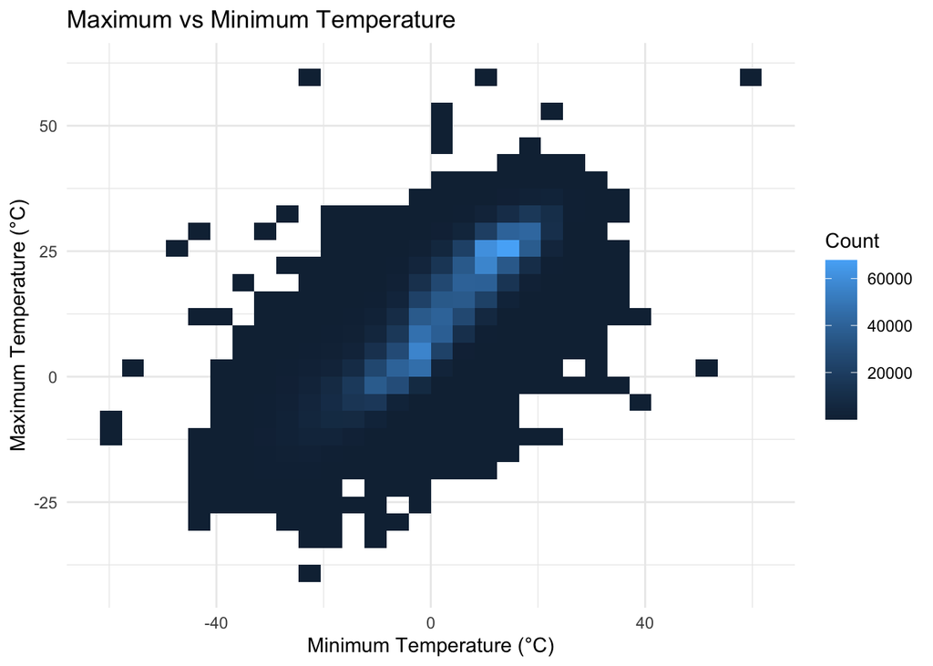

```r
tt_plot =
  ggplot(
    ny_noaa_clean,
    aes(x = tmin, y = tmax)
  ) +
  geom_bin2d() +
  labs(
    title = "Maximum vs Minimum Temperature",
    x = "Minimum Temperature (°C)",
    y = "Maximum Temperature (°C)",
    fill = "Count"
  ) +
  theme_minimal()

tt_plot
```

(ii)the distribution of snowfall values greater than 0 and less than 100 separately by year

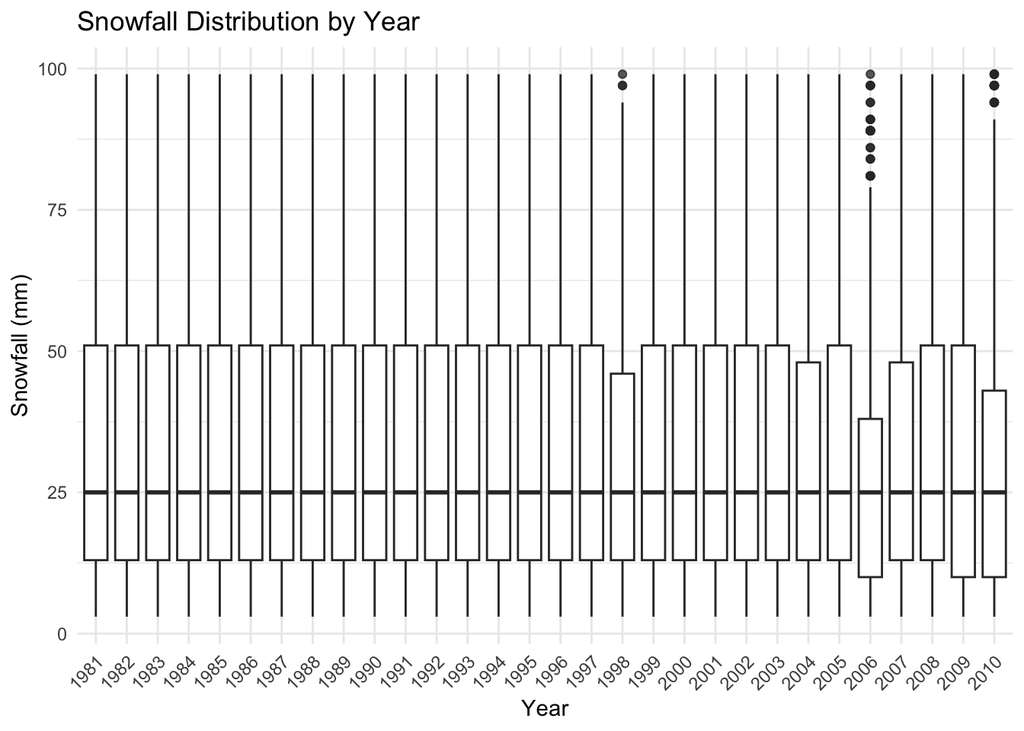

```r
snowfall_data =
  ny_noaa_clean |>
  filter(
    !is.na(snow),
    snow > 0,
    snow < 100
  )

snowfall_plot =
  ggplot(
    snowfall_data,
    aes(x = factor(year), y = snow)
  ) +
  geom_boxplot(outlier.alpha = 0.3) +
  labs(
    title = "Snowfall Distribution by Year",
    x = "Year",
    y = "Snowfall (mm)"
  ) +
  theme_minimal() +
  theme(
    axis.text.x = element_text(
      angle = 45,
      hjust = 1
    )
  )

snowfall_plot
```

#Problem 2

Data Import, Cleaning, and Merging

```r
nhanes_covar =
  read_csv(
    "https://p8105.com/data/nhanes_covar.csv",
    skip = 4
  ) |>
  clean_names() |>
  filter(age >= 21) |>
  drop_na() |>
  mutate(
    sex = factor(
      sex,
      levels = c(1, 2),
      labels = c("Male", "Female")
    ),
    education = factor(
      education,
      levels = c(1, 2, 3),
      labels = c(
        "Less than high school",
        "High school equivalent",
        "More than high school"
      )
    )
  )
nhanes_accel =
  read_csv(
    "https://p8105.com/data/nhanes_accel.csv"
  ) |>
  clean_names()
nhanes_df =
  inner_join(nhanes_covar, nhanes_accel, by = "seqn")
```

2.1 Number of Men and Women in Each Education Category

```r
nhanes_df |>
  count(education, sex) |>
  pivot_wider(
    names_from = sex,
    values_from = n,
    values_fill = 0
  ) |>
  kable(
    col.names = c("Education", "Men", "Women"),
    caption = "Number of Participants by Sex and Education"
  )
```

Number of Participants by Sex and Education

| Education | Men | Women |
| --- | --- | --- |
| Less than high school | 27 | 28 |
| High school equivalent | 35 | 23 |
| More than high school | 56 | 59 |

2.2 Age Distributions by Sex and Education Category

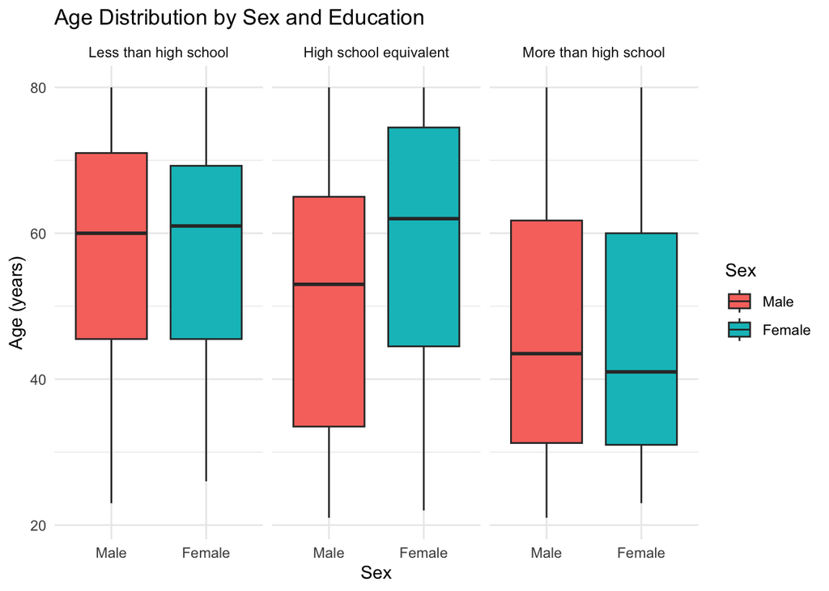

```r
age_plot =
  ggplot(
    nhanes_df,
    aes(x = sex, y = age, fill = sex)
  ) +
  geom_boxplot() +
  facet_wrap(~ education) +
  labs(
    title = "Age Distribution by Sex and Education",
    x = "Sex",
    y = "Age (years)",
    fill = "Sex"
  ) +
  theme_minimal()

age_plot
```

The table shows how the numbers of male and female participants differ across education categories. The boxplots allow us to compare the age distributions of men and women within each education category, including their medians, variability, and potential outliers. Differences in age distributions across education groups may reflect demographic differences among participants. The specific conclusions should be based on the observed table and plots.

2.3 Total Daily Activity Versus Age

```r
nhanes_df =
  nhanes_df |>
  mutate(
    total_activity = rowSums(
      across(min1:min1440),
      na.rm = TRUE
    )
  )
```

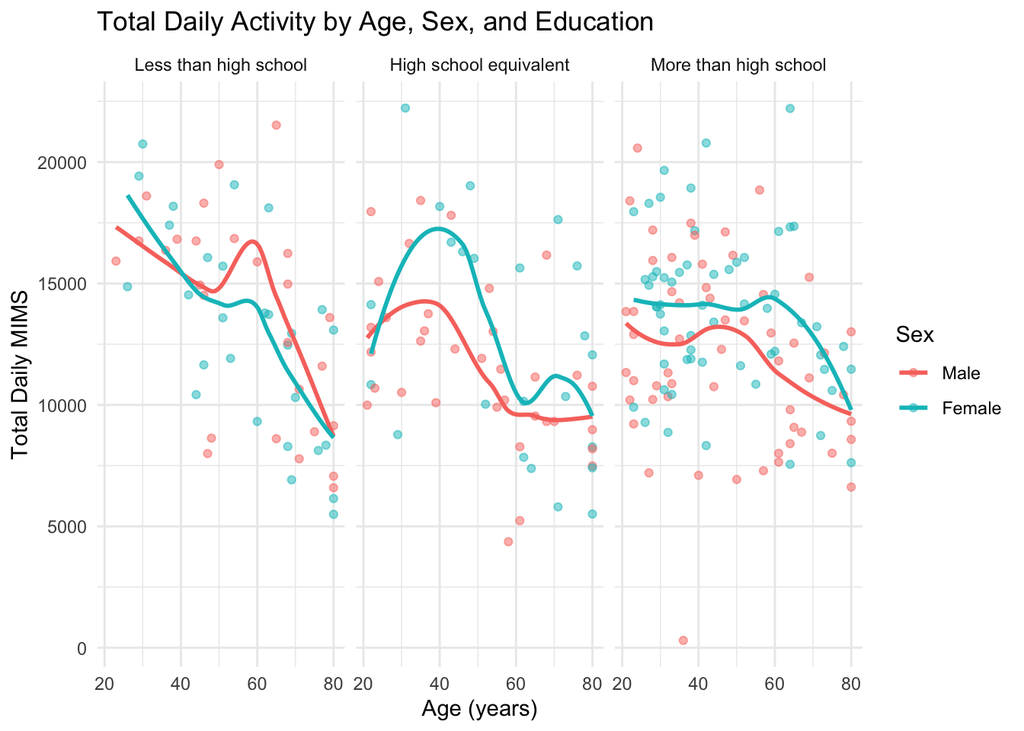

```r
total_activity_plot =
  ggplot(
    nhanes_df,
    aes(
      x = age,
      y = total_activity,
      color = sex
    )
  ) +
  geom_point(alpha = 0.5) +
  geom_smooth(se = FALSE) +
  facet_wrap(~ education) +
  labs(
    title = "Total Daily Activity by Age, Sex, and Education",
    x = "Age (years)",
    y = "Total Daily MIMS",
    color = "Sex"
  ) +
  theme_minimal()

total_activity_plot
```

The scatterplots show the relationship between age and total daily activity across education categories, with separate smooth trends for men and women. The smooth curves help identify whether activity tends to increase or decrease with age and whether the patterns differ by sex or education. The degree of overlap and separation between the curves can also indicate differences in total activity between men and women. These patterns describe associations and do not establish causal relationships.

2.4 Twenty-Four-Hour Activity Time Courses

```r
activity_by_time =
  nhanes_df |>
  pivot_longer(
    cols = min1:min1440,
    names_to = "minute",
    names_prefix = "min",
    values_to = "mims"
  ) |>
  mutate(
    minute = as.integer(minute)
  ) |>
  group_by(education, sex, minute) |>
  summarize(
    mean_activity = mean(mims, na.rm = TRUE),
    .groups = "drop"
  )
```

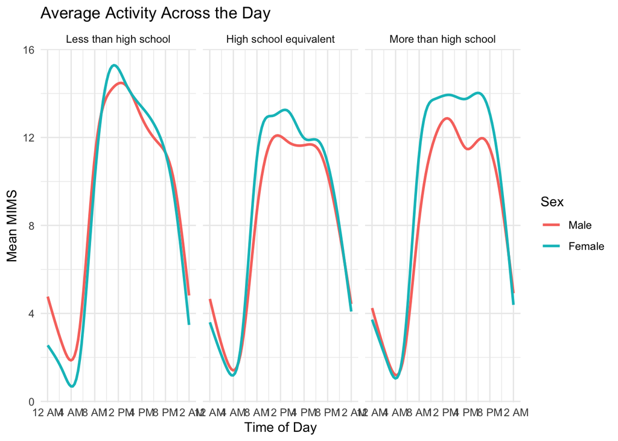

```r
daily_activity_plot =
  ggplot(
    activity_by_time,
    aes(
      x = minute,
      y = mean_activity,
      color = sex
    )
  ) +
  geom_smooth(
    se = FALSE,
    span = 0.08
  ) +
  facet_wrap(~ education, nrow = 1) +
  scale_x_continuous(
    breaks = seq(0, 1440, by = 240),
    labels = c("12 AM", "4 AM", "8 AM",
               "12 PM", "4 PM", "8 PM", "12 AM")
  ) +
  labs(
    title = "Average Activity Across the Day",
    x = "Time of Day",
    y = "Mean MIMS",
    color = "Sex"
  ) +
  theme_minimal()

daily_activity_plot
```

The three panels show how average activity changes throughout the day for men and women in each education category. The smooth curves help identify periods of relatively high and low activity and make it easier to compare daily patterns between sexes. Similar curve shapes would suggest similar daily activity patterns, whereas differences in curve height or timing would suggest differences in average activity levels or when activity occurs. Any specific claims about peak activity times or differences between groups should be based on the plotted curves.

#Problem 3

Data Import

```r
zip_files = c(
  "data/citibike/Jan 2020 Citi.csv.zip",
  "data/citibike/Jan 2024 Citi.csv.zip",
  "data/citibike/July 2020 Citi.csv.zip",
  "data/citibike/July 2024 Citi.csv.zip"
)

data_dir = "data/citibike"
dir.create(
  data_dir,
  recursive = TRUE,
  showWarnings = FALSE
)

walk(zip_files, ~ unzip(.x, exdir = data_dir))
```

```r
csv_files = c(
  "data/citibike/Jan 2020 Citi.csv",
  "data/citibike/Jan 2024 Citi.csv",
  "data/citibike/July 2020 Citi.csv",
  "data/citibike/July 2024 Citi.csv"
)

citibike_raw =
  map2_dfr(
    csv_files,
    c(2020L, 2024L, 2020L, 2024L),
    \(file, yr) {
      read_csv(file, show_col_types = FALSE) |>
        clean_names() |>
        mutate(
          year = yr,
          month = if_else(
            str_detect(file, "Jan"),
            1L,
            7L
          )
        )
    }
  )
```

3.1

```r
citibike_df =
  citibike_raw |>
  mutate(
    ride_duration = as.numeric(duration),
    day_of_week = factor(
      weekdays,
      levels = c(
        "Monday", "Tuesday", "Wednesday",
        "Thursday", "Friday", "Saturday", "Sunday"
      )
    ),
    member_casual = factor(
      member_casual,
      levels = c("casual", "member")
    ),
    rideable_type = factor(rideable_type)
  ) |>
  filter(
    !is.na(ride_duration),
    ride_duration > 0,
    ride_duration < 240
  )
```

The Citi Bike dataset contains 99485 rides and 11 variables after combining the four monthly datasets and removing records with invalid timestamps or ride durations. Each row represents one bike ride. The variables include ride identifiers, bike type, start and end times, station information, and membership status. Additional variables were created for ride duration in minutes, year, month, and day of the week. The dataset contains a 1% sample of rides lasting less than four hours in January and July of 2020 and 2024, rather than all Citi Bike rides.

3.2

```r
ride_counts =
  citibike_df |>
  count(year, month, member_casual) |>
  pivot_wider(
    names_from = member_casual,
    values_from = n,
    values_fill = 0
  ) |>
  mutate(
    month = factor(
      month,
      levels = c(1, 7),
      labels = c("January", "July")
    )
  ) |>
  arrange(year, month)

ride_counts |>
  kable(
    col.names = c(
      "Year", "Month", "Casual Riders", "Members"
    ),
    caption = "Total Rides by Year, Month, and Membership Status"
  )
```

Total Rides by Year, Month, and Membership Status

| Year | Month | Casual Riders | Members |
| --- | --- | --- | --- |
| 2020 | January | 984 | 11436 |
| 2020 | July | 5637 | 15411 |
| 2024 | January | 2108 | 16753 |
| 2024 | July | 10894 | 36262 |

The table compares the number of rides taken by casual riders and members across the four sampled months. Differences between membership groups may reflect differences in how frequently each group uses Citi Bike. Comparing January and July also helps assess seasonal patterns, while comparing the same month across years helps assess changes over time. Because the dataset is a 1% sample, the counts represent rides in the sample rather than all rides in the Citi Bike system.

3.3

```r
top_stations =
  citibike_df |>
  filter(year == 2024, month == 7) |>
  filter(!is.na(start_station_name)) |>
  count(
    start_station_name,
    name = "number_of_rides",
    sort = TRUE
  ) |>
  slice_head(n = 5)

top_stations |>
  kable(
    col.names = c("Starting Station", "Number of Rides"),
    caption = "Five Most Popular Starting Stations in July 2024"
  )
```

Five Most Popular Starting Stations in July 2024

| Starting Station | Number of Rides |
| --- | --- |
| Pier 61 at Chelsea Piers | 163 |
| University Pl & E 14 St | 155 |
| W 21 St & 6 Ave | 152 |
| West St & Chambers St | 150 |
| W 31 St & 7 Ave | 146 |

The table identifies the five most popular starting stations in the July 2024 sample. Stations with higher counts may serve as important residential, commuting, or recreational locations. The counts describe sampled rides originating at each station, not the complete system-wide totals.

3.4

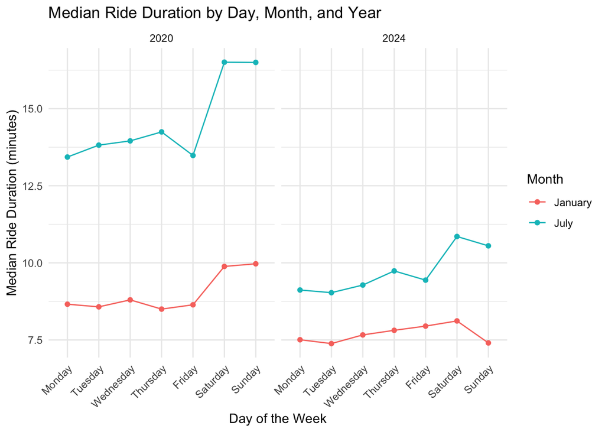

```r
median_duration =
  citibike_df |>
  group_by(year, month, day_of_week) |>
  summarize(
    median_duration = median(ride_duration),
    .groups = "drop"
  )

ggplot(
  median_duration,
  aes(
    x = day_of_week,
    y = median_duration,
    color = factor(month),
    group = month
  )
) +
  geom_line() +
  geom_point() +
  facet_wrap(~year) +
  scale_color_discrete(
    name = "Month",
    labels = c("January", "July")
  ) +
  labs(
    title = "Median Ride Duration by Day, Month, and Year",
    x = "Day of the Week",
    y = "Median Ride Duration (minutes)"
  ) +
  theme_minimal() +
  theme(axis.text.x = element_text(angle = 45, hjust = 1))
```

The plot compares median ride duration across weekdays, months, and years. Differences between weekdays and weekends may indicate that rides serve different purposes on different days. Differences between January and July may reflect seasonal changes in riding behavior. Comparing the two year panels reveals whether these patterns differ between 2020 and 2024. The median provides a measure of typical ride duration that is less sensitive to unusually long rides than the mean.

3.5

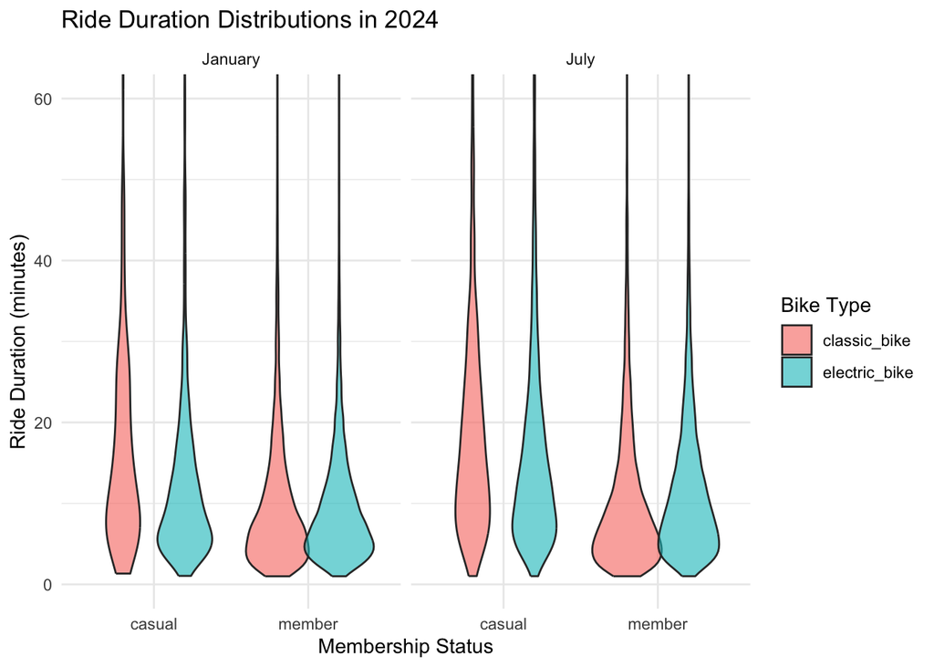

```r
citibike_2024 =
  citibike_df |>
  filter(year == 2024) |>
  mutate(
    month_label = factor(
      month,
      levels = c(1, 7),
      labels = c("January", "July")
    )
  )

ggplot(
  citibike_2024,
  aes(
    x = member_casual,
    y = ride_duration,
    fill = rideable_type
  )
) +
  geom_violin(
    alpha = 0.6,
    position = position_dodge(width = 0.8),
    trim = TRUE
  ) +
  facet_wrap(~month_label) +
  coord_cartesian(ylim = c(0, 60)) +
  labs(
    title = "Ride Duration Distributions in 2024",
    x = "Membership Status",
    y = "Ride Duration (minutes)",
    fill = "Bike Type"
  ) +
  theme_minimal()
```

The figure compares ride-duration distributions by month, membership status, and bike type in 2024. The violin shapes show where ride durations are more concentrated and how widely they vary. Differences between casual riders and members may indicate differences in riding behavior, while differences between bike types may reflect how riders use traditional and electric bicycles. Comparing January and July also provides information about seasonal variation. The vertical axis is limited to 60 minutes for readability, but the underlying data are not removed by this display limit.